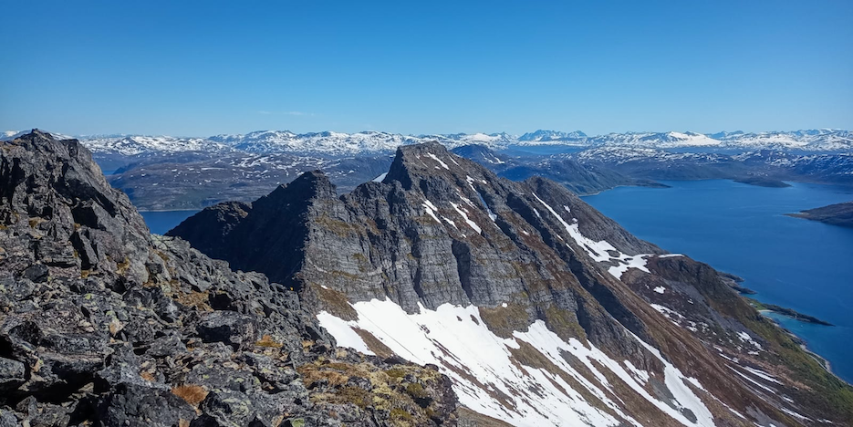

[Coastal barometer blog](https://kystbarometeret.com) | [Coastal barometer website](https://kystbarometeret2021.vercel.app) |

# Preparing covariates for the analysis of seafood production

Marina Espinasse

2021-09-09

```r
library(vroom)
library(here)
```

# 1 Import the data

Data on fisheries and aquaculture production are ready to be used. The other data series need to be cleaned.

First, fisheries catch and aquaculture production tables. Note, that aquaculture production table is loaded from another repository, nor-data. This is a closed repository, and aquaculture data is held there until Fisheries Directorate allow to share them

```r
aqua <- read.csv(file.path("~/github/nor-data/aquaculture/aquaculture_production_per_municipality.csv"))

aqua_prep <- aqua %>%
  select(-feed_kg) %>%
  rename(aqua_prod = production_final)
```

Fisheries data still includes catch per species, I will take a sum of all species catches, to get a total fisheries production in tons

```r
fish <- read.csv(here("prep", "output_data", "catch_total_per_mcp.csv"))

fish_prep <- fish %>%
  clean_names(.) %>%
  rename(municip = municip_name_new,
         total_catch = total_catch_new) |>
  group_by(year, municip, municip_number) |>
  summarize(total_catch = sum(total_catch, na.rm = T)) |>
  filter(year >= 2005 & year <= 2019)
```

Sea area of each municipality: I clean the data by removing covariates we don’t need and renaming the others. Sea area data can be found at https://www.kartverket.no/til-lands/fakta-om-norge/storleiken-pa-landet

```r
sea <- read_excel(here("prep", "raw_data", "KommArea.xlsx"))

sea_prep <- sea %>%
  clean_names(.) %>%
  select(-c(fastland_og_yer, kid, total_areal)) %>%
  rename(sea_area = havflate,
         municip_number = komnum,
         municip = name)
```

# 2 Covariates data

## 2.1 Gator dataset

The Gator data xxset of municipality level statistic. I downloaded this data set from: https://dataverse.no/file.xhtml?fileId=2140&version=1.1

```r
gator <-vroom(here("prep", "raw_data", "gatorsub.csv"), delim = ",")
```

```r
gator_prep <-gator %>%
  filter(fylke %in% c("17", "18", "19")) %>%
  filter(year  >= 2005 & year <= 2018 ) %>%
  select(c(komnr,
           kommune,
           year,
           fylke,
           natinnby,
           innbypros,
           poprate,
           arb_led,
           )) %>%
  mutate(municip_pop = natinnby*innbypros/100) %>%
  mutate(municip_pop_ths = municip_pop/1000)
```

Rename variables to English

```r
gator_prep2 <- gator_prep |>
  select(-c(natinnby,innbypros)) |>
  rename(municip_number = komnr,
         municip=kommune,
         county = fylke,
         pop_growth = poprate,
         unemp = arb_led)
```

# 3 SSB variables

## 3.1 Wage coefficient

On the meeting 8th of September, we decided to exclude wage coefficient from the analysis, because it cannot predict either fisheries or aquacutlure. I will keep the code for preparing wage coefficient, but will exclude it from the covariates final table.

Next dataset is p90p10 index. I will rename this index to “wageco”, for “wage coefficient”. Source of the dataset: https://www.ssb.no/inntekt-og-forbruk/artikler-og-publikasjoner/slik-maler-ssb-ulikhet

```r
wageco <- read_excel(here("prep", "raw_data", "gini_p10_wagescoeff.xlsx"),
                     range = "A4:AE91",
                     .name_repair = ~janitor::make_clean_names(.))

wageco_prep <- wageco |>
  select(c(1,18:31)) |>
  separate(x, into = c("municip_number", "municip"), sep = " ") |>
  mutate_at(.vars = c(3:16), as.numeric) |>
  pivot_longer(cols = c(3:16)) |>
  mutate(year = str_extract_all(name, "[:digit:]{4}")
         )

wageco_prep2 <- wageco_prep |>
  select(-name) |>
  rename(wageco = value) |>
  mutate_at(.vars = c("year", "municip_number"), as.numeric) |>
  mutate(wageco = as.numeric(as.character(wageco)))
```

7 missing values in the wage ratios data - those are all data from Harstad municipality

```r
filter(wageco_prep2, is.na(wageco))
```

```
## # A tibble: 7 × 4
##   municip_number municip wageco  year
##            <dbl> <chr>    <dbl> <dbl>
## 1           1903 Harstad     NA  2005
## 2           1903 Harstad     NA  2006
## 3           1903 Harstad     NA  2007
## 4           1903 Harstad     NA  2008
## 5           1903 Harstad     NA  2009
## 6           1903 Harstad     NA  2010
## 7           1903 Harstad     NA  2011
```

## 3.2 Population growth

Population and growth: https://www.ssb.no/statbank/table/01222/

Gator has too many missing observations: 275 out of 1044 for population growth, 174 for unemployment, and also 129 for population (not all years’ records present). Instead, I will use Statistics Norway data that seem to be complete (and are quality controlled)

```r
popgrowth <- read_excel(here("prep", "raw_data", "Folketilvekst10.xlsx"),
                         range = "A3:C5658",
        .name_repair = ~janitor::make_clean_names(.)
          )

popgrowth_prep <- popgrowth |>
  fill(x) |>
  separate(x, into = c("municip_number", "municip"), sep = " ") |>
  rename(popgrowth = folkevekst) |>
  mutate(year = str_sub(x_2, start = 1, end = 4)) |>
  mutate(quarter = str_sub(x_2, start = 5, end = 6)) |>
  select(-x_2)
```

For the population growth variable, I will choose the values of growth only for the first quarter of the year. All variables in the analysis will be per year so no reason to have growth per quarter.

```r
popgrowth_prep2 <- popgrowth_prep |>
  filter(quarter == "K1") |>
  mutate_at(.vars = c("year", "municip_number"), as.numeric) |>
  mutate(popgrowth = as.numeric(as.character(popgrowth)))
```

No missing values in the population growth

## 3.3 Municipalities’ population

```r
pop <- read_excel(here("prep", "raw_data", "Folkemengde.xlsx"),
                         range = "A3:S90",
        .name_repair = ~janitor::make_clean_names(.)
          )

pop_prep <- pop |>
  select(c(2:16)) |>
  separate(x_2, into = c("municip_number", "municip"), sep = " ") |>
  mutate_at(.vars = c(3:16), as.numeric) |>
  pivot_longer(cols = c(3:16)) |>
  mutate(year = str_extract_all(name, "[:digit:]{4}")
         )
pop_prep2 <- pop_prep |>
  select(-name) |>
  rename(population = value) |>
  mutate_at(.vars = c("year", "municip_number"), as.numeric) |>
  mutate(population = as.numeric(as.character(population)))
```

No NAs in the municipalities’ population values

## 3.4 Unemployment

Unemployed: https://www.ssb.no/statbank/table/10594

Here the data is per month, but we need just one value per uear. Similar to population growth, I will use the data for January only

```r
unemp <- read_excel(here("prep", "raw_data", "arbeidsledige.xlsx"),
                         range = "A3:D11139",
        .name_repair = ~janitor::make_clean_names(.)
          )

unemp_prep <- unemp |>
  fill(x) |>
  select(-x_2) |>
  separate(x, into = c("municip_number", "municip"), sep = " ") |>
  mutate(year = str_sub(x_3, start = 1, end = 4)) |>
  mutate(month = str_sub(x_3, start = 5, end = 7)) |>
  select(-x_3) |>
  rename(unemployed = personer_registrert_helt_arbeidsledige) |>
  mutate_at(.vars = c("year", "municip_number"), as.numeric)
```

I see that in some cases, the unemployment values are available for selected months only. For instance, unemployment in Hammerfest was registered only for November in years 2015-2018. If I filter by the first month, I will get a lot of NA. Instead, I will use the value of the earliest month with the data, for instance, if the first unemployment record was in March - I will use March data instead of January.

```r
unemp_prep2 <- unemp_prep |>
  mutate(month_num = str_sub(month, start = 2, end = 3)) |>
  mutate(month_num = as.numeric(month_num)) |>
  select(-month) |>
  group_by(municip_number, municip, year) |>
  arrange(month_num) |>
  slice_head(n = 1) |>
  mutate(unemployed = as.numeric(as.character(unemployed)))
```

In the unemployment, there are still 95 missing values (also in the raw data). Not sure what caused them, but the SSB is the best source of data, if they recorded NA it is probably true lack of data.

## 3.5 Workforce among 15-74 years old

Percent in workforce: https://www.ssb.no/statbank/table/06445

```r
wforce <- read_excel(here("prep", "raw_data", "Sysselsatte.xlsx"),
                         range = "A3:S90",
        .name_repair = ~janitor::make_clean_names(.)
          )

wforce_prep <- wforce |>
  select(c(2:18)) |>
  select(-c(x_3,x_4)) |>
  separate(x_2, into = c("municip_number", "municip"), sep = " ") |>
  mutate_at(.vars = c(3:16), as.numeric) |>
  pivot_longer(cols = c(3:16)) |>
  mutate(year = str_extract_all(name, "[:digit:]{4}")
         )
wforce_prep2 <- wforce_prep |>
  select(-name) |>
  rename(percent_wforce = value) |>
  mutate_at(.vars = c("year", "municip_number"), as.numeric) |>
  mutate(percent_wforce = as.numeric(as.character(percent_wforce)))
```

## 3.6 Projection on the coastline - geography covariate

This is a covariate we decided to add to the analysis on the meeting on 8th of September. It is ready made, and was calculated as: the projection of each municipality’s center on the line following Norwegian coast. Then, the distance from the southern-most point of the coastline (border with Sweden, in the south) to each projection point was calculated. The further north and north-east the municipality is located, the larger the distance from the start of the coastline.

I will rand the distance from 1 to max, to have all covariates in a similar scale

```r
geo <- read.csv(here("prep", "raw_data", "grunnlinje_midpoint_kom.csv"), sep = ";", skip = 2)

geo_prep <-geo |>
  select(c(KomNr,DistanceGrunnlinja.km.)) |>
  rename(municip_number = KomNr,
         distance = DistanceGrunnlinja.km.) |>
  mutate(distance_rank = rank(distance))
```

# 4 Joining all the data into a single data set

Just left-joining all the tables.

```r
spfood_data <- aqua_prep |>
  left_join(fish_prep, by = c("year", "municip_number")) |>
  select(-municip.y) |>
  rename(municip = municip.x) |>
  left_join(sea_prep[,c(1,2)], by = "municip_number") |>
  #left_join(wageco_prep2[,-2], by = c("municip_number", "year")) |>
  left_join(pop_prep2[,c(1,3,4)], by = c("municip_number", "year")) |>
  left_join(popgrowth_prep2[,c(1,3,4)], by = c("municip_number", "year")) |>
  left_join(unemp_prep2[,c(1,3,4)], by = c("municip_number", "year")) |>
  left_join(wforce_prep2[,c(1,3,4)],by=c("municip_number", "year")) |>
  left_join(geo_prep,by=c("municip_number"))
```

# 5 Check how much data is missing per varialbe

There are 862 observations in total. There are 133 observations, where total catch of fish is NA. These are municipality by year combination, where catches were not registered in a given municipality. In such cases, we can assume that fisheries production was zero. There are also 35 observations where unemployment data is not available.

```r
map(spfood_data, ~ sum(is.na(.x)))
```

```
## $year
## [1] 0
##
## $county
## [1] 0
##
## $municip_number
## [1] 0
##
## $municip
## [1] 0
##
## $aqua_prod
## [1] 0
##
## $total_catch
## [1] 133
##
## $sea_area
## [1] 0
##
## $population
## [1] 0
##
## $popgrowth
## [1] 0
##
## $unemployed
## [1] 35
##
## $percent_wforce
## [1] 0
##
## $distance
## [1] 0
##
## $distance_rank
## [1] 0
```

Replace NA in total catch with zeros, replace negative aquaculture production with NA. Then,I also divide the aquaculture production by 1000 to convert kg to tons.

```r
spfood_data_final <- spfood_data |>
  mutate(total_catch = replace(total_catch,
                               is.na(total_catch),
                               0
          )
  ) |>
  mutate(aqua_prod = ifelse(
    aqua_prod < 0,
    NA,
    aqua_prod
  )) |>
  mutate(aqua_prod_ton = aqua_prod/1000) |>
  mutate(total_catch_ton = total_catch)
```

# 6 Filtering municipalities with at leat 10 years of data

For the spatial-temporal analysis, I will need only the municipalities for which we have at least 10 years of data. We cannot account for temporal correlation with less than 10 years of data, or it would be a very poor model with misspecified parameters. Here is the dataset with 59 municipalities that had at least 10 years of data

There are 817 observations left

```r
spfood_data_final_selected <-spfood_data_final |>
  dplyr::group_by(municip) |>
  dplyr::mutate(totobs = n()) |>
  filter(totobs >= 10)
```

# 7 Save final tables

```r
#write.csv(spfood_data_final, here("prep", "output_data", "spfood_allvars.csv"), row.names = FALSE)
```

```r
#write.csv(spfood_data_final_selected, here("prep", "output_data", "mcp_59selected.csv"), row.names = FALSE)
```